# Effects of Skagit Precipitation Patterns on Steelhead Smolt Outmigration

## Project Introduction

Precipitation patterns control characterstics of a stream ecosystem.

- Discharge
- Temperature
- Habitat

Organisms, inclusing anadromous fish rely on the natural flow regime.

- Evolved experiencing natural disturbances
- Time life cycle with seasonal changes/distrubance

## Project Introduction cont.

The Skagit river has relatively natural flow regime

- Natural fish barrier downstream of all dams
- Allows for mostly natural transient hydrology

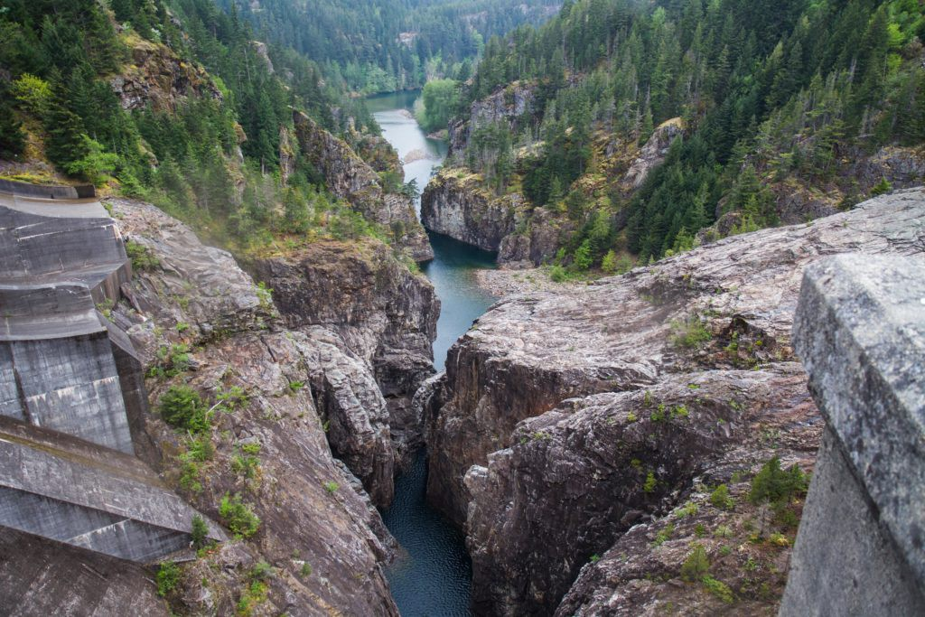

## Steelhead Lifecycle

Smolt outmigrate in spring

- have the ability to choose when they migrate (age)

What causes variable timing in migration?

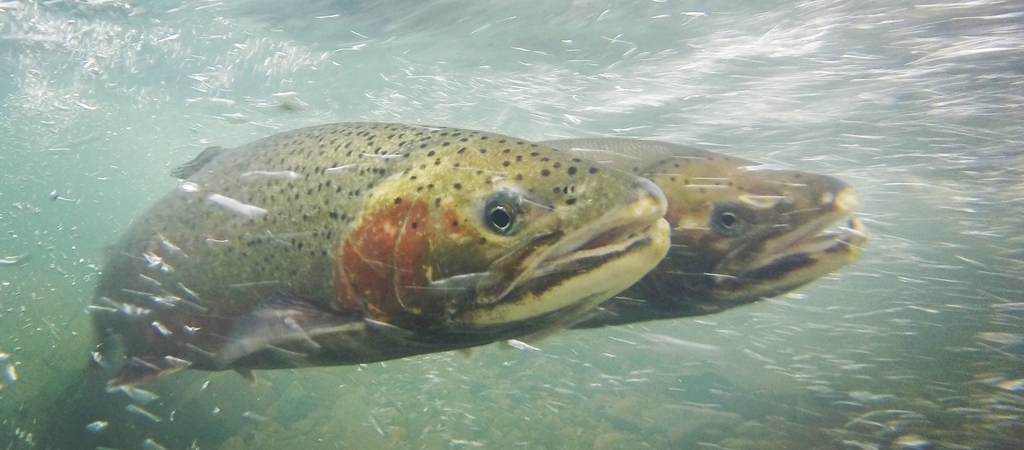

## Required Packages

```r
library(tidyverse)
```

Specific package use will include

- Dplyr
- GGPlot

## Data 1: Monthly Discharge

| year | 1 | 2 | 3 | 4 | 5 | 6 |
| --- | --- | --- | --- | --- | --- | --- |
| 1941 | 10310 | 8654 | 8487 | 11080 | 15880 | 14970 |
| 1942 | 7636 | 7626 | 6856 | 11510 | 16870 | 25400 |
| 1943 | 11730 | 11970 | 11600 | 23360 | 21660 | 31420 |
| 1944 | 9965 | 8044 | 7878 | 10610 | 17400 | 19620 |
| 1945 | 15950 | 14860 | 9714 | 10130 | 25960 | 25370 |

Holds the average discharge for each month of the year from 1941 to 2018.

- Each variable header represents the month of the year
- Discharge is in cubic feet per second

## Data 2: Daily Discharge

| month | day | day.of.year | mean |
| --- | --- | --- | --- |
| 1 | 1 | 1 | 15600 |
| 1 | 2 | 2 | 15600 |
| 1 | 3 | 3 | 16600 |
| 1 | 4 | 4 | 16800 |
| 1 | 5 | 5 | 17700 |

Each mean value represents the average discharge for that day of the year.

- Discharge given in cubic feet per second
- Mean calculated from data dating 1941 to 2018

## Data 3: Smolt Trap Catch

| year | smolt..screw. | smolt..scoop. |
| --- | --- | --- |
| 1990 | na | 198 |
| 1991 | na | 301 |
| 1992 | na | 332 |
| 1993 | 663 | 304 |
| 1994 | 1297 | 601 |

Each smolt value represents the number of smolt caught in a specific type of trap for that year. Trap catches steelhead smolt outmigrants on Skagit river with data from 1990-2007.

## Annual Skagit Hydrograph

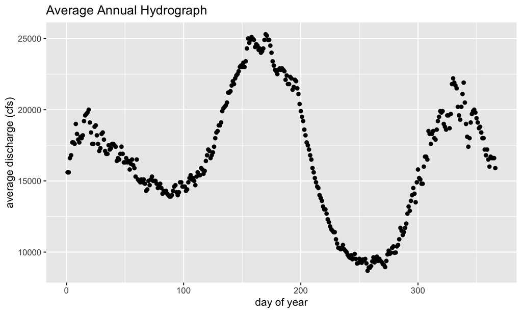

Plot graphs average daily discharge values against day of year to show average year of discharge for Skagit river.

## Annual Skagit Hydrograph cont.

Plot indicates a precipitation pattern dominated by both rain and snow.

## Late Spring Discharge

| may | june | year | late_spring |
| --- | --- | --- | --- |
| 15880 | 14970 | 1941 | 30850 |
| 16870 | 25400 | 1942 | 42270 |
| 21660 | 31420 | 1943 | 53080 |
| 17400 | 19620 | 1944 | 37020 |
| 25960 | 25370 | 1945 | 51330 |

- Modified table to show only average discharge of May and June
- Also includes sum average discharge for two months for later analysis

## Late Spring Discharge vs Smolt Outmigration

```r
discharge_and_smolt <- inner_join(late_spring_discharge,
                                  yearly_smolt, by = "year")
```

| may | june | year | late_spring | smolt..screw. | smolt..scoop. |
| --- | --- | --- | --- | --- | --- |
| 17460 | 24930 | 1990 | 42390 | na | 198 |
| 20860 | 22150 | 1991 | 43010 | na | 301 |
| 16010 | 13430 | 1992 | 29440 | na | 332 |
| 22900 | 18050 | 1993 | 40950 | 663 | 304 |

## Late Spring Discharge vs Smolt Outmigration cont.

- Joined tables of late spring discharge and yearly smolt migration
- Preparation for analysis between discharge and smolt catch

Analysis

- regression test for relationship
- x-axis = late spring discharge
- y-axis = smolt catch (scoop for highest sample size)

## Late Spring Discharge vs Smolt Outmigration Analysis

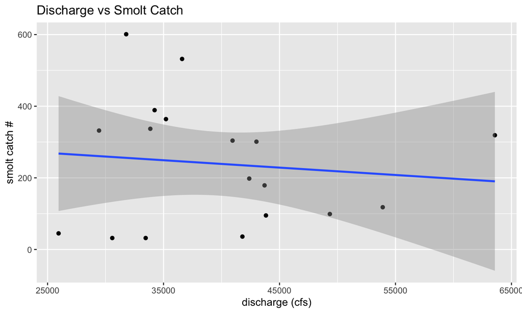

```
##
## Call:
## lm(formula = smolt..scoop. ~ late_spring, data = discharge_and_smolt)
##
## Residuals:
##     Min      1Q  Median      3Q     Max
## -226.29 -132.15   15.56  107.80  345.18
##
## Coefficients:
##               Estimate Std. Error t value Pr(>|t|)
## (Intercept) 321.301397 187.157316   1.717    0.105
## late_spring  -0.002061   0.004601  -0.448    0.660
##
## Residual standard error: 177.9 on 16 degrees of freedom
## Multiple R-squared:  0.01238,    Adjusted R-squared:  -0.04935
## F-statistic: 0.2006 on 1 and 16 DF,  p-value: 0.6603
```

## Potential Climate Change Analysis

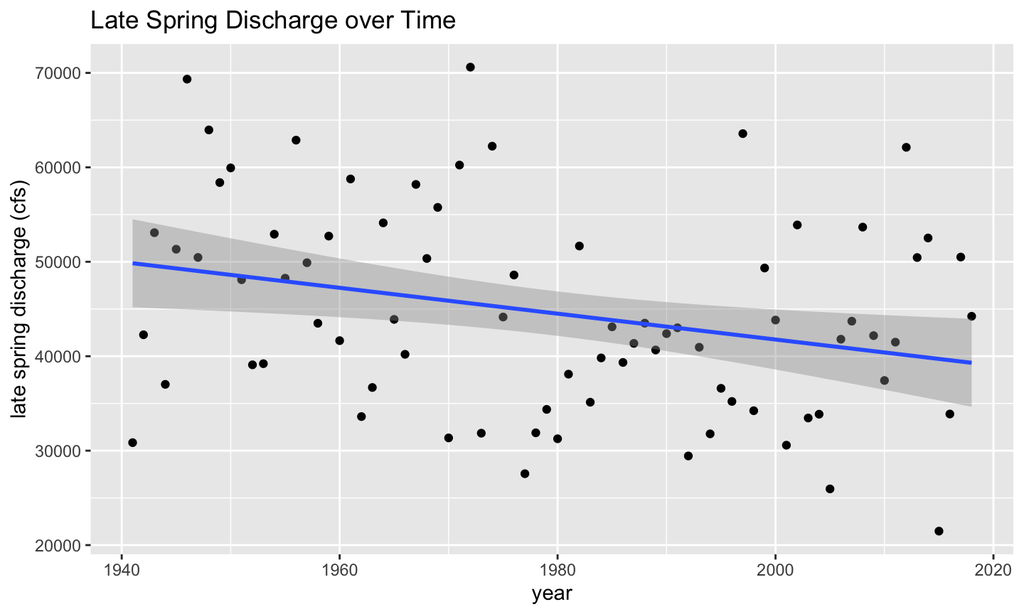

```
##
## Call:
## lm(formula = late_spring ~ year, data = late_spring_discharge)
##
## Residuals:
##      Min       1Q   Median       3Q      Max
## -18995.9  -7718.5   -544.2   7432.3  25008.5
##
## Coefficients:
##              Estimate Std. Error t value Pr(>|t|)
## (Intercept) 315603.33  103794.65   3.041  0.00324 **
## year          -136.92      52.43  -2.611  0.01086 *
## ---
## Signif. codes:  0 '***' 0.001 '**' 0.01 '*' 0.05 '.' 0.1 ' ' 1
##
## Residual standard error: 10430 on 76 degrees of freedom
## Multiple R-squared:  0.08234,    Adjusted R-squared:  0.07026
## F-statistic: 6.819 on 1 and 76 DF,  p-value: 0.01086
```

## Future Research

More data on a shorter timescale

- More years of smolt catch (2007-present)
- Weekly/daily catch numbers

Threat of climate change

- important to understand relationship
- Timing/intensity of discharge likely to change

## Challenges

- Importing data without commas
- Resizing images to fit in the presentation
- Completing and displaying results of linear regression
- Pulling correct columns for analysis tables